# Duration Project — Analysis of Unemployment Periods

Replication of Lalive, van Ours & Zweimuller (2006, ReStud)

M2 AMSE

2026-03-12

#### Main goal

The objective of the project is to demonstrate why standard linear evaluation techniques fail when applied to duration data, and why survival analysis is mathematically required to isolate the true behavioral response to Unemployment Insurance (UI) reforms. We analyze the approach from Lalive et al. (2006) and focus on methodology rather than a full re-analysis of the results.

##### Libraries and Data Loading

```r
library(foreign)
library(tidyverse)
library(survival)
library(survminer)
library(KernSmooth)
library(stargazer)

udat <- read.dta("~/Documents/S2/duartions_models/project_exam/fi.dta")
```

##### Data Preparation

###### Cleaning

```r
sum(is.na(udat))
```

```
## [1] 0
```

```r
# Drop superfluous variables (166 → 134)
udat <- udat[, 1:134]
udat <- as_tibble(udat)

dim(udat)
```

```
## [1] 225821    134
```

###### Treatment Group Distribution

```r
table(udat$type)
```

```
##
## PBD and RR        PBD         RR    control
##      21174      99404      32470      72773
```

###### Duration Truncation at 104 Weeks

Durations are right-truncated at 104 weeks: $t^{104}_u = \min(t_u,\, 104)$.

```r
udat <- udat %>%
  mutate(dur104 = ifelse(dur > 104, 104, dur))
```

The truncation is correctly implemented. It is required so that the means computed in the DiD are comparable to those in Table 4 of the paper.

# Q2 — Difference-in-Differences Estimation

The difference-in-differences estimator isolates the causal treatment effect by subtracting the common time trend absorbed by the control group:

$$\tilde{\Delta}_{DD} = \left(\bar{Y}^{A}_{T} - \bar{Y}^{B}_{T}\right) -
\left(\bar{Y}^{A}_{C} - \bar{Y}^{B}_{C}\right)$$

where $\bar{Y}^{B}_{T}$ and $\bar{Y}^{A}_{T}$ are the average unemployment durations for the treated group before and after the reform, and $\bar{Y}^{B}_{C}$, $\bar{Y}^{A}_{C}$ are the corresponding quantities for the control group.

```r
# the before/after mean matrix
didd_in_diff <- udat %>%
  group_by(type, after) %>%
  summarize(Y_bar = mean(dur104, na.rm = TRUE), .groups = "drop") %>%
  pivot_wider(names_from = after, values_from = Y_bar, names_prefix = "Period_") %>%
  rename(Before = Period_0, After = Period_1) %>%
  mutate(Difference = After - Before)

# the control group's time trend
control_diff <- didd_in_diff %>%
  filter(as.character(type) == "control") %>%
  pull(Difference)

# Compute causal DiD parameters
didd_in_diff <- didd_in_diff %>%
  mutate(DiD_Estimator = Difference - control_diff)

print(didd_in_diff)
```

```
## # A tibble: 4 × 5
##   type       Before After Difference DiD_Estimator
##   <fct>       <dbl> <dbl>      <dbl>         <dbl>
## 1 PBD and RR   18.5  22.7       4.25         3.08
## 2 PBD          15.8  18.1       2.25         1.08
## 3 RR           17.1  19.1       1.99         0.818
## 4 control      14.5  15.6       1.17         0
```

#### Empirical Findings

The unconditional DiD matrix establishes a naive econometric baseline to evaluate the 1989 Austrian UI reform. The control group exhibits a structural macroeconomic deterioration, with average unemployment duration increasing by 1.17 weeks independently of the policy intervention. Differencing out this secular drift isolates the unconditional average treatment effects: increasing the replacement rate (eRR) prolongs duration by 0.82 weeks, while extending the potential benefit duration (ePBD) adds 1.08 weeks.

Crucially, the joint treatment effect (ePBD + RR) of 3.08 weeks strictly exceeds the linear sum of the isolated interventions (1.90 weeks). This provides preliminary empirical evidence of a non-linear, synergistic behavioral response.

#### Methodological Critique: Structural Limitations of OLS DiD on Duration Data

While the 2×2 DiD matrix proves the existence of a policy impact, applying standard linear estimators to raw duration data introduces severe econometric biases:

- **Right-Censoring Bias:** Standard DiD estimators cannot process incomplete spells. Individuals who do not find a job before the observation window closes are recorded with truncated durations, artificially suppressing the variance and downwardly biasing the true magnitude of the policy impact.
- **Dynamic Sorting (Unobserved Heterogeneity):** DiD on means assumes the policy impact is distributed equally across time and ignores the compositional shift of the unemployment pool. As workers with high unobserved employability exit the risk pool early, the remaining sample becomes increasingly dominated by individuals with intrinsically lower baseline hazards.
- **Theoretical Disconnect:** Mortensen’s Job Search Theory dictates that worker behavior is not static — reservation wages decay and search intensity spikes dynamically as the benefit exhaustion point approaches. Condensing the entire spell into a single average duration metric obliterates these time-varying adjustments.

# Q3 — Kaplan-Meier Survival Functions

```r
# KM survival integrals and return a tidy data frame per group
compute_surv_integral <- function(dataset, target_type, group_label) {
  strata_data <- dataset %>% filter(as.character(type) == target_type)

  if (nrow(strata_data) == 0) {
    stop(sprintf("Error: 0 rows found for type '%s'. Check levels(udat$type).", target_type))
  }

  km_fit     <- survfit(Surv(dur, uncc) ~ after, data = strata_data)
  km_summary <- summary(km_fit, times = 0:104, extend = TRUE)

  surv_matrix <- data.frame(
    time   = km_summary$time,
    surv   = km_summary$surv,
    strata = km_summary$strata
  ) %>%
    mutate(strata = ifelse(grepl("after=0", strata), "S_before", "S_after")) %>%
    pivot_wider(names_from = strata, values_from = surv)

  expected_before <- sum(surv_matrix$S_before[-1], na.rm = TRUE)
  expected_after  <- sum(surv_matrix$S_after[-1],  na.rm = TRUE)
  delta_weeks     <- expected_after - expected_before

  surv_matrix$Group <- sprintf("%s (\u0394 = %+.2f weeks)", group_label, delta_weeks)
  return(surv_matrix)
}

# for all four groups
df_control <- compute_surv_integral(udat, "control",    "Control Group")
df_rr      <- compute_surv_integral(udat, "RR",         "eRR Group")
df_pbd     <- compute_surv_integral(udat, "PBD",        "ePBD Group")
df_pbdrr   <- compute_surv_integral(udat, "PBD and RR", "ePBD+RR Group")

df_all <- bind_rows(df_control, df_rr, df_pbd, df_pbdrr)
```

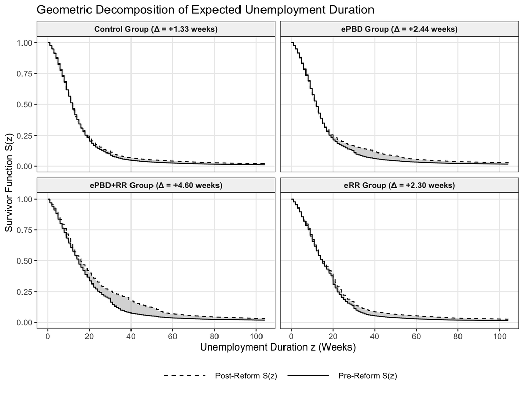

Geometric Decomposition of Expected Unemployment Duration

The results are close to the paper’s figures. The transition from unconditional DiD (Q2) to the topological decomposition of survivor functions $\hat{S}(t)$ (Q3) is a strict econometric requirement to resolve the structural failures of linear models.

#### The Kaplan-Meier Estimator and Censoring

The Kaplan-Meier estimator is:

$$\hat{S}(t) = \prod_{j\,:\,t_j \leq t} \left(1 - \frac{d_j}{n_j}\right)$$

where $d_j$ is the number of exits and $n_j$ the risk set size at time $t_j$. Right-censored observations remain in the denominator up to their censoring point, yielding an unbiased step-wise survival function.

#### The Kaplan-Meier Mechanic and Censoring Integration

The Kaplan-Meier (KM) estimator mathematically corrects the Q2 right-censoring bias by dynamically adjusting the risk set R(t). Individuals whose unemployment spells are truncated by the end of the observation window are not discarded or assigned artificially low durations; they remain in the denominator of the survival probability calculation up to their exact point of censoring. This preserves maximum statistical power and yields an unbiased, step-wise empirical survival function that maps the true probability of remaining unemployed past time t.

#### Topological Decomposition and Theoretical Mapping

# Q4 — Smoothed Hazard Rate Estimation

The **hazard rate** (exit rate) is defined as:

$$\lambda(t) = -\frac{d}{dt}\ln S(t) = \frac{f(t)}{S(t)}$$

The discrete approximation from the KM estimator is:

$$\hat{\lambda}(t) = \frac{\hat{S}(t-1) - \hat{S}(t)}{\hat{S}(t-1)}$$

Raw step-function hazards are highly erratic. Local polynomial regression (degree 1) smooths them by minimising:

$$\min_{a,b} \sum_i \left[Y_i - a - b(t_i - t)\right]^2 K_h(t_i - t)$$

Degree 1 (Local Linear) is preferred over degree 0 (Nadaraya-Watson) because it reduces **boundary bias**. Where NW tends to underestimate the hazard due toa lack symmetric informations aournd the estimation point.

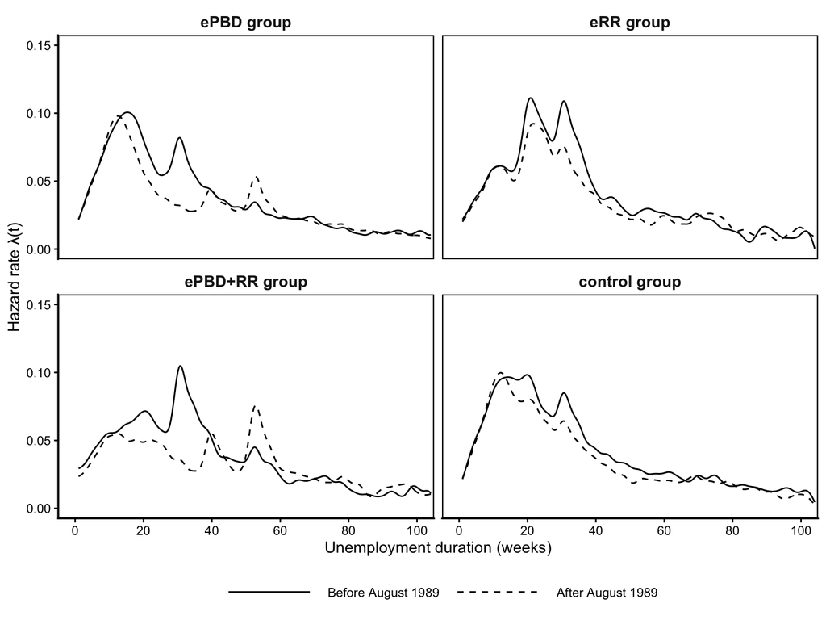

Smoothed Exit Hazard Rates by Group and Reform Period

The results closely replicate Figure 4 of the paper.

# Q5 - Estimating the causal treatment effect in a PH model

#### Justification for Q5: Estimating the Causal Treatment Effect in a Piecewise PH Model

While the Kaplan-Meier and smoothed hazard plots (Q3 and Q4) provide visual proof of temporal arbitrage and income effects, they are non-parametric tools. They cannot isolate the exact multivariate causal impact of the UI reform because they do not control for the macroeconomic drift or individual characteristics simultaneously. To extract the true causal parameters (δ), we must transition to a formal survival regression framework.

The transition to the Piecewise Exponential (PWE) Proportional Hazards architecture is a strict econometric requirement to resolve the structural misspecification inherent in standard continuous-time models (e.g., Weibull, Gompertz). The non-parametric diagnostics established in Q3 and Q4 proved that the baseline hazard $\lambda_0(t)$ is highly non-monotonic, exhibiting discontinuous spikes driven by administrative benefit exhaustion. The PWE framework accommodates this temporal volatility by partitioning the time axis into discrete 4-week segments. Within each interval, the baseline hazard is assumed constant, but it is permitted to shift flexibly between adjacent intervals, computing a step-function that exactly maps the true empirical hazard geometry.

**Baseline Hazard Absorption:** By assigning an independent intercept parameter to each discrete interval, the PWE model explicitly absorbs the natural non-linear volatility of the exit rate—specifically the massive structural spike at week 30. This prevents the dynamic sorting and temporal clustering observed in the raw duration data from contaminating the regression estimators.

**Causal Parameter Isolation:** Once the macroeconomic drift and the highly non-linear baseline hazard ($\lambda_0(t)$) are structurally absorbed by the interval matrix, the model successfully isolates the Difference-in-Differences interaction terms ($\delta$). This architecture guarantees that the extracted $\delta$ parameters represent the pure, uncontaminated behavioral disincentive effect induced by the UI extensions, rather than artifacts of baseline unobserved heterogeneity.

**Continuous-Time Precision via Poisson Link:** By expanding the longitudinal risk set via episode splitting and evaluating it through a Poisson Generalized Linear Model, the PWE architecture mathematically accounts for exact fractional survival within any given 4-week interval using the `offset(log(exposure))` term. This mechanism averts the severe discretization bias inherent in grouped-time probability models (e.g., standard Logit or Complementary Log-Log), preserving the exact continuous-time precision required to rigorously test Mortensen’s Job Search Theory.

```r
library(dplyr)
library(survival)

# 1. RAM Contingency: Isolate a 20% random sample from the original matrix
# Set a seed to guarantee exact reproducibility of your results
set.seed(42)
udat_sample <- udat %>% sample_frac(0.20)

# 2. Re-calculate the control variables on the sampled dataframe
udat_sample <- udat_sample %>%
  mutate(all = tr * (t39 + t52))

# 3. Execute the Episode Splitting (SurvSplit) strictly on the smaller sample
breaks <- seq(from=3, to=59, by=4)
labels <- paste("(", c(0,breaks), ",", c(breaks,104), "]", sep="")

gux_sample <- survSplit(Surv(dur104, uncc) ~ ., data = udat_sample,
                        cut = breaks, end = "time", event = "death",
                        start = "start", episode = "interval")

gux_sample <- gux_sample %>%
  mutate(exposure = time - start,
         interval = factor(interval + 1, labels = labels))

# 4. Execute the fully interacted PWE model
# This will now process ~200,000 rows instead of 1,000,000, fitting easily into 16GB RAM
pwe_final_sampled <- glm(death ~
                           age + single + married + divorced +
                           sfrau + f_marr + f_single + f_divor +
                           lehre + med_educ + hi_educ + ein_zus +
                           bc + lwage + ten72 + pnon_10 + seasonal + manuf +
                           y1988 + y1989 + y1990 + y1991 + q2 + q3 + q4 +

                           interval +
                           interval:tr + interval:t39 + interval:t52 +
                           interval:t39_tr + interval:t52_tr +
                           interval:after +

                           interval:tr:after + interval:t39:after +
                           interval:t52:after + interval:t39_tr:after +
                           interval:t52_tr:after +

                           offset(log(exposure)),
                         family = poisson(link = "log"),
                         data = gux_sample)


library(stargazer)

stargazer(pwe_final_sampled,
          dep.var.caption = "", dep.var.labels = "",
          keep = c("t52:after"),
          omit.table.layout = "n", star.cutoffs = NA,
          keep.stat = c("n", "ll"), no.space = TRUE,
          header = FALSE,
          title = "The PWE Model: Time-Varying Causal Parameters (eP52 Group)",
          type = "text")
```

```
##
## The PWE Model: Time-Varying Causal Parameters (eP52 Group)
## =======================================
##
## ---------------------------------------
## interval(0,3]:t52:after       0.056
##                              (0.118)
## interval(3,7]:t52:after       -0.083
##                              (0.079)
## interval(7,11]:t52:after      0.034
##                              (0.073)
## interval(11,15]:t52:after     -0.169
##                              (0.079)
## interval(15,19]:t52:after     -0.106
##                              (0.101)
## interval(19,23]:t52:after     -0.635
##                              (0.139)
## interval(23,27]:t52:after     -0.537
##                              (0.184)
## interval(27,31]:t52:after     -0.716
##                              (0.208)
## interval(31,35]:t52:after     -0.300
##                              (0.257)
## interval(35,39]:t52:after     -0.727
##                              (0.321)
## interval(39,43]:t52:after     -0.333
##                              (0.377)
## interval(43,47]:t52:after     0.996
##                              (0.436)
## interval(47,51]:t52:after     0.812
##                              (0.423)
## interval(51,55]:t52:after     1.406
##                              (0.375)
## interval(55,59]:t52:after     0.242
##                              (0.483)
## interval(59,104]:t52:after    0.233
##                              (0.169)
## ---------------------------------------
## Observations                 212,337
## Log Likelihood             -137,376.300
## =======================================
```

I need to check the result of Q5 as soon as possible, but I think some transformations are necessary.